# Code Through: rtweet, Twitter Stats in R

Andres Gonzalez

April 24, 2021

# Welcome to rtweet

Have you ever wanted to access Twitter stats in your R Markdown files?  
Of course you have!

# What Is “rtweet”?

This package allows you to collect Twitter data through their REST and stream API.

1. search_tweets()
2. stream_tweets()
3. get_trends()
4. get_favorites()

## Installing & Loading

You can install “rtweet” with function ‘install.packages()’ and load it with ‘library()’. For visualization, we will use ggplot2.

```r
install.packages("rtweet")
library(rtweet)
library(gglot2)
```

## Search for tweets by hashtag

Lets search for tweets with #datascience

**NOTE: You need a Twitter account to use this, it will automatically sign into the Twitter API from your browser when you first try to access.**

**NOTE 2: If you want to use more advanced features like this, you have to sign up and request user credentials from Twitter’s developer program.**

*[Twitter Dev Tools Application](https://developer.twitter.com/en/apply-for-access)

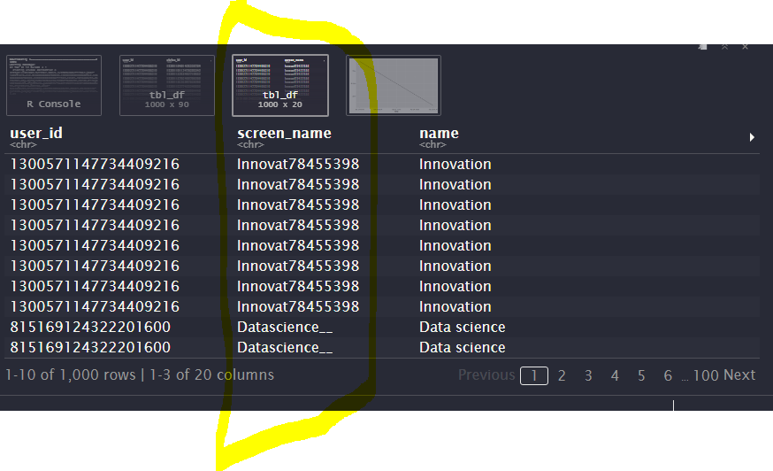

```r
## search for 1000 tweets using the datascience hashtag
rt <- search_tweets(
  "#datascience", n = 1000, include_rts = FALSE
)

## preview tweets data
rt

## preview users data
users_data(rt)

## plot time series (need ggplot2)
ts_plot(rt)
```

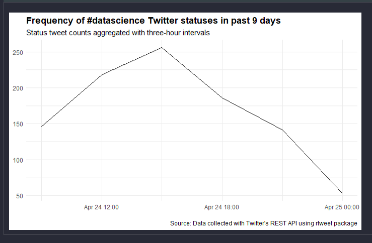

```r
## plot time series of tweets
ts_plot(rt, "3 hours") +
  ggplot2::theme_minimal() +
  ggplot2::theme(plot.title = ggplot2::element_text(face = "bold")) +
  ggplot2::labs(
    x = NULL, y = NULL,
    title = "Frequency of #datascience Twitter statuses in past 9 days",
    subtitle = "Status tweet counts aggregated with three-hour intervals",
    caption = "\nSource: Data collected with Twitter's REST API using rtweet package"
  )
```

This function is best used to gather and aggregate data. There is a search limit cap of 18,000 every 15 minutes, you can change this limit.

Use ’ retryonratelimit = TRUE ’ to search beyond 18k cap.

```r
## search for 250,000 tweets containing the word data
rt <- search_tweets(
  "data", n = 250000, retryonratelimit = TRUE
)
```

## Function: stream_tweets()

Get a random 1% sample of live tweets. The "" symbol will sample all tweets. I like ’ lookup_coords(“phoenix, us”) ’ to stream by geography.

```r
## stream tweets from london for 60 seconds
rt <- stream_tweets(lookup_coords("phoenix, us"), timeout = 15)
```

This is pretty powerful, we can save this stream as a .json object and now we have a dataset.

```r
## stream london tweets for a week (60 secs x 60 mins * 24 hours *  7 days)
stream_tweets(
  lookup_coords("phoenix, us"),
  timeout = 15,
  file_name = "phoenixtempetweets.json",
  parse = FALSE
)

## read in the data as a tidy tbl data frame
ptt <- parse_stream("phoenixtempetweets.json")
```

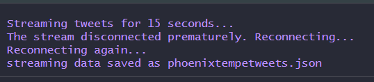

## Function : get_trends()

This is a simple one, collect the trend from a location and view it as a dataframe.

```r
phx <- get_trends("phoenix")

phx
```

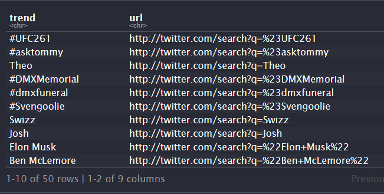

##Function : get_favorites()

```r
sd <- get_favorites("SunDevilWBB", n = 100)

sd
```

[figure not shown]

# Discussion

This package is a powerful tool to leverage Twitter’s API. We can bring those Twitter API responses into R to use for analysis.

There is an official R package named “twitteR” that is more robust that this open-sourced package shown in this Code-Through. This is where developers go to use Twitter’s API with their official credentials to integrate with their own applications. I chose to use “rtweet” because it does not require credentials to receive responses for simple commands.

# Further Resources

View the following materials to learn more about package “rtweet”.

- [**GitHub Documentation**](https://github.com/ropensci/rtweet)